# Module 7

Dan Miller

2023-10-20

```r
library(sf)
library(tidyverse)
```

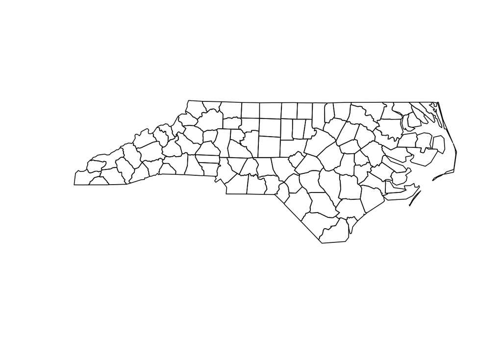

```r
NC <- read_sf("NC_Region/NC_Region.shp")

plot(st_geometry(NC))
```

# Question 1

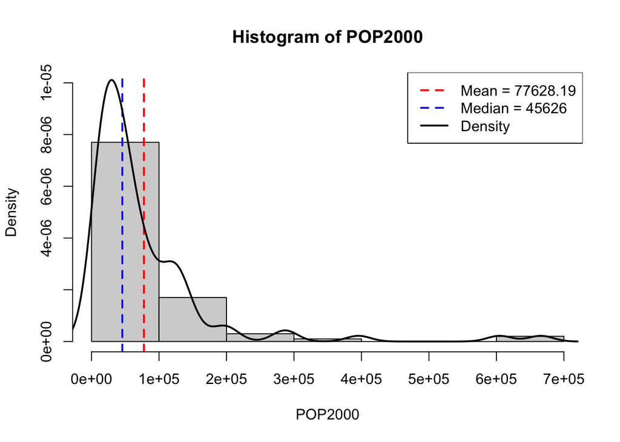

```r
# Create the histogram with density
hist_data <- hist(NC$POP2000, main = "Histogram of POP2000", prob = TRUE, xlab = "POP2000", ylab = "Density", ylim = c(0, 10e-06))

# Creating population mean, median, and density  objects
mean_value <- mean(NC$POP2000)
median_value <- median(NC$POP2000)
density_values <- density(NC$POP2000)

# creating lines based on the above
abline(v = mean_value, col = "red", lty = 2, lwd = 2)
abline(v = median_value, col = "blue", lty = 2, lwd = 2)
lines(density_values, col = "black", lty = 1, lwd = 2)

# Adding a legend
legend("topright", legend = c(paste("Mean =", round(mean_value, 2)),
                              paste("Median =", round(median_value, 2)),
                              "Density"),
       col = c("red",
               "blue",
               "black"), lty = c(2,2,1), lwd = 2)
```

```r
# Show the histogram
```

### Scatterplots

**1) Raw Data**

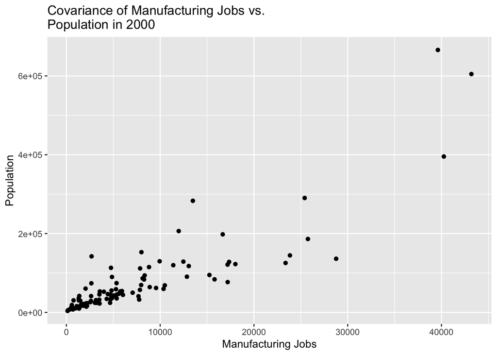

```r
library(ggplot2)
ggplot(
data = NC,
mapping = aes(x = MNEM2000, y = POP2000)
) +
geom_point() +
labs(
x = "Manufacturing Jobs",
y = "Population",
# The "\n" character is a "newline" escape character and can be used to
# break up long titles onto more than one line.
title = "Covariance of Manufacturing Jobs vs.\nPopulation in 2000")
```

**2) Transformed Data**

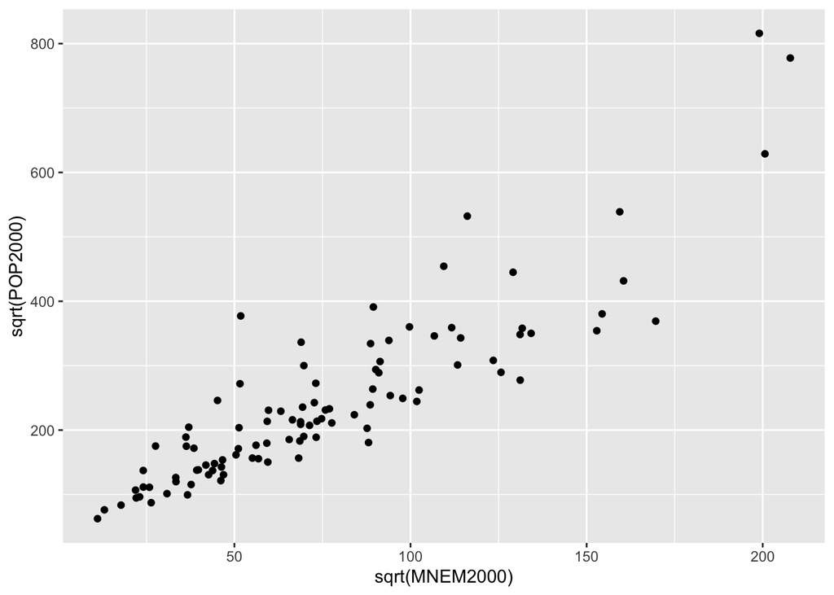

```r
ggplot(data = NC, mapping = aes(x = sqrt(MNEM2000), y = sqrt(POP2000))) +
         geom_point()
```

### Testing Covariance Using Pearson’s R

```r
library(corrr)
cor <- NC %>%
# We'll drop the 'geometry' on the fly, as it can potentially break the
# function. We're not actually getting rid of it from our original data, of
# course.
st_drop_geometry() %>%

  dplyr::select(MNEM2000, POP2000) %>%
correlate(use = "pairwise.complete.obs",
method = "pearson")
```

```
## Correlation computed with
## • Method: 'pearson'
## • Missing treated using: 'pairwise.complete.obs'
```

```r
# The fashion() function in corrr is used to format the results of correlation
# for printing; all it does is make things look nicer in our output!
fashion(cor, decimals = 4)
```

```
##       term MNEM2000 POP2000
## 1 MNEM2000            .8702
## 2  POP2000    .8702
```

```r
## term MNEM2000 POP2000
## 1 MNEM2000 .8702
## 2 POP2000 .8702
```

The Pearson’s R for these two variables seems like a strongly positive result – as the population increases, so does manufacturing employment. We might also like to explore correlations between numerous variables at the same time; it’s easy to do with the corrr package and dplyr. Because we’re only looking at numeric data, we can filter out both the geometry column, as well as any character columns:

```r
NC_filter <- NC %>%

# Again, we need to drop the geometry
st_drop_geometry() %>%

# Using select_if, we can choose only the columns that are numeric
select_if(is.numeric) %>%

# Finally, we can choose the columns we actually want to correlate. Note that
# this is a bit redundant with the `select_if()` above, but I wanted to  show
# how to select columns programmatically with a logical test.
dplyr::select(
c(
POP2000,
MNEM2000,
HOUSEHOLDS,
MEDIANRENT,
TOTJOB2000,
WHITE,
BLACK,
AMERI_ES,
ASIAN_PI,
OTHER,
HISPANIC
)
)
```

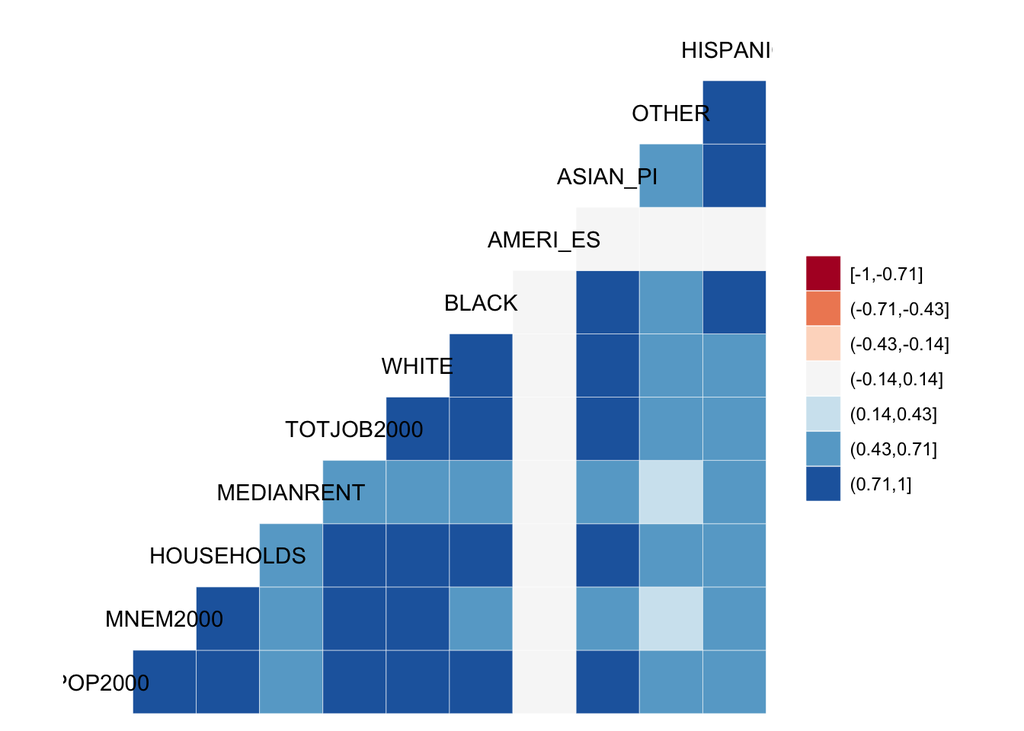

```r
# We can plot a correlogram with the GGally package. Install and load it, and
# use the `ggcorr()` function on our filtered data to get a plot
# install.packages("GGally")
library(GGally)
NC_filter %>%
# We can set a diverging color palette if we set the nbreaks argument. Use
# RColorBrewer::brewer.pal.info to see some of the available color palettes in
# R.
ggcorr(nbreaks = 7, palette = "RdBu")
```

# Question 2

Using the correlate() and fashion() functions in corrr, create a Pearson’s r correlation matrix of your filtered data. When filtering and selecting columns, choose different/additional columns to compare (don’t just use the ones in the Lab!). Provide the matrix and the correlogram (and your R code used to make it!) in your R Markdown report. Identify the strongest and weakest correlation coefficients where r < 1.

```r
#NC
```

### My Correlation Matrix

```r
my_df <- NC %>%
  st_drop_geometry() %>%
  select(
         POP90_SQMI,
         TOTJOB1990,
         MEDIAN_VAL,
         MEDIANRENT,
         WHITE,
         BLACK,
         HISPANIC,
         AMERI_ES,
         ASIAN_PI,
         OTHER,
         MARRIED,
         DIVORCED,
         NEVERMARRY


         )

 # Using `correlate`, with pearson method to create a correlation matrix object
correlation_matrix <- correlate(my_df, method = "pearson")
```

```
## Correlation computed with
## • Method: 'pearson'
## • Missing treated using: 'pairwise.complete.obs'
```

```r
# Calling fashion()  to print out correlation matrix
fashion(correlation_matrix)
```

```
##          term POP90_SQMI TOTJOB1990 MEDIAN_VAL MEDIANRENT WHITE BLACK HISPANIC
## 1  POP90_SQMI                   .88        .53        .66   .87   .82      .56
## 2  TOTJOB1990        .88                   .51        .65   .99   .92      .72
## 3  MEDIAN_VAL        .53        .51                   .90   .54   .40      .33
## 4  MEDIANRENT        .66        .65        .90              .68   .50      .49
## 5       WHITE        .87        .99        .54        .68         .85      .67
## 6       BLACK        .82        .92        .40        .50   .85            .73
## 7    HISPANIC        .56        .72        .33        .49   .67   .73
## 8    AMERI_ES        .04        .12       -.09       -.06   .04   .14      .10
## 9    ASIAN_PI        .75        .91        .51        .61   .87   .89      .82
## 10      OTHER        .42        .57        .23        .39   .52   .60      .98
## 11    MARRIED        .87       1.00        .52        .66   .99   .89      .71
## 12   DIVORCED        .89        .99        .51        .64   .99   .91      .66
## 13 NEVERMARRY        .87        .99        .53        .65   .96   .94      .71
##    AMERI_ES ASIAN_PI OTHER MARRIED DIVORCED NEVERMARRY
## 1       .04      .75   .42     .87      .89        .87
## 2       .12      .91   .57    1.00      .99        .99
## 3      -.09      .51   .23     .52      .51        .53
## 4      -.06      .61   .39     .66      .64        .65
## 5       .04      .87   .52     .99      .99        .96
## 6       .14      .89   .60     .89      .91        .94
## 7       .10      .82   .98     .71      .66        .71
## 8                .06   .09     .09      .09        .13
## 9       .06            .69     .89      .89        .93
## 10      .09      .69           .57      .50        .55
## 11      .09      .89   .57              .99        .97
## 12      .09      .89   .50     .99                 .98
## 13      .13      .93   .55     .97      .98
```

### My Correlogram

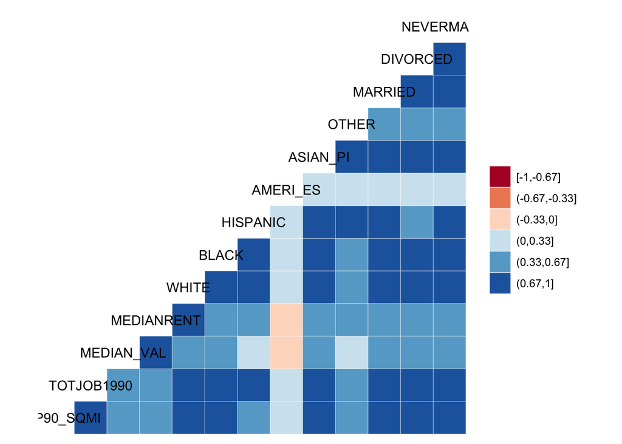

```r
## Taking my df and creating a correlogram
my_df %>%
# We can set a diverging color palette if we set the nbreaks argument. Use
# RColorBrewer::brewer.pal.info to see some of the available color palettes in
# R.
ggcorr(nbreaks = 6, palette = "RdBu")
```

**Highest Correlation:**

WHITE & TOTJOB1990,  
TOTJOB1990 & NEVERMARRY,  
WHITE & MARRIED,  
WHITE & DIVORCED.

**Lowest Correlation:**

Everything in the AMERI_ES has low correlation: **(-.09 to 0.14)**  
MEDIAN_VAL & OTHER: **0.23**  
MEDIAN_VAL & HISPANIC: **0.33**

### Regression

```r
model <- lm(MNEM2000 ~ POP2000, data = NC)
model
```

```
##
## Call:
## lm(formula = MNEM2000 ~ POP2000, data = NC)
##
## Coefficients:
## (Intercept)      POP2000
##   1.891e+03    7.294e-02
```

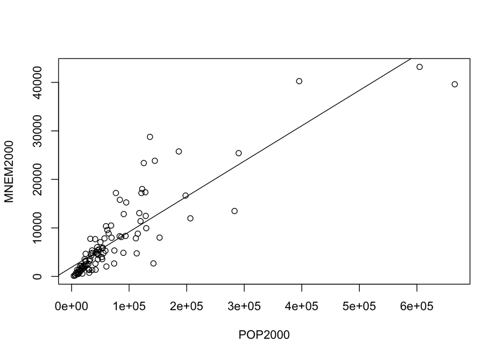

```r
##
## Call:
## lm(formula = MNEM2000 ~ POP2000, data = NC)
##
## Coefficients:
## (Intercept) POP2000
## 1.891e+03 7.294e-02
# What we get is the classic equation of a line: 𝑦 = 𝑚𝑥 + 𝑏, where 𝑏 is our (Intercept) and
# 𝑚 is our POP2000 coefficient. We can plot this in R on top of a scatter plot:
model <- lm(MNEM2000 ~ POP2000, data = NC)
plot(MNEM2000 ~ POP2000, data = NC)
abline(model)
```

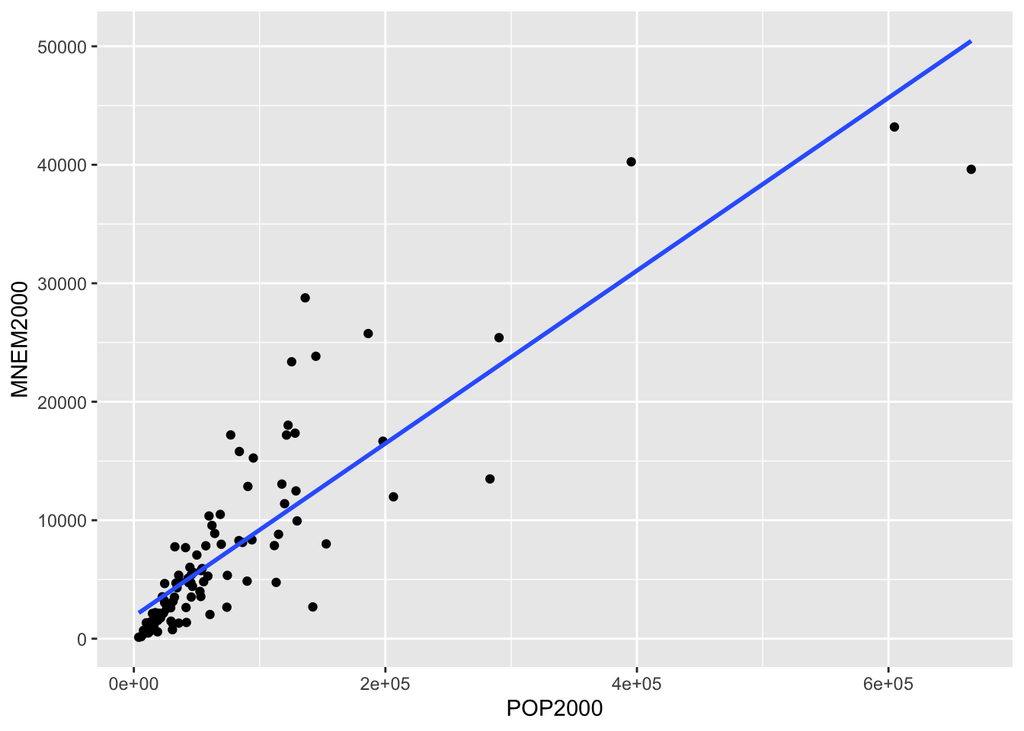

```r
library(ggplot2)
ggplot(NC, aes(x = POP2000, y = MNEM2000)) +
geom_point() +
# `se = FALSE` means we don't plot a confidence interval around our line.
stat_smooth(method = "lm", se = FALSE)
```

```r
s <- summary(model)
s
```

```
##
## Call:
## lm(formula = MNEM2000 ~ POP2000, data = NC)
##
## Residuals:
##      Min       1Q   Median       3Q      Max
## -10836.5  -2051.7   -973.5    912.1  16942.0
##
## Coefficients:
##              Estimate Std. Error t value Pr(>|t|)
## (Intercept) 1.891e+03  5.368e+02   3.522 0.000652 ***
## POP2000     7.294e-02  4.171e-03  17.485  < 2e-16 ***
## ---
## Signif. codes:  0 '***' 0.001 '**' 0.01 '*' 0.05 '.' 0.1 ' ' 1
##
## Residual standard error: 4281 on 98 degrees of freedom
## Multiple R-squared:  0.7573, Adjusted R-squared:  0.7548
## F-statistic: 305.7 on 1 and 98 DF,  p-value: < 2.2e-16
```

```r
s$r.squared
```

```
## [1] 0.7572621
```

Larger 𝑟 values for a bivariate regression line indicate that more of the variance in y is 2 explained by the variance in x. In other words, this means that roughly 76% of manufacturing in each county is explained by the population of that county; this also means that ≈ 24% of variance is not explained by population. There’s clearly more to the story, such as how manufacturing is distributed geographically around the state in a certain way, but we’ve now established that population is an important part of our model.

### Resdiuals

```r
model <- lm(MNEM2000 ~ POP2000, data = NC)
head(model$residuals)
```

```
##          1          2          3          4          5          6
##  -640.8329 -1265.6555  3589.3870 -2683.4450 -1682.8900 -1520.8310
```

# Question 3

Calculate and report the mean value of the set of residuals from your regression results (in other words, the mean difference between predicted and observed values of our dependent variable). Next, create an absolute value histogram of the residuals from your regression using the ‘fd’ breaks method. Add the mean value of the residuals to your plot as a vertical line. Include a legend, appropriate axis labels, and a title. As always, provide your R code to do this in your R Markdown report. We now have two “goodness of fit” measures to help us decide if our prediction line fits our data well. A higher r^2 value in combination with a lower standard error estimate gives us some confidence that our line of fit is suitable.

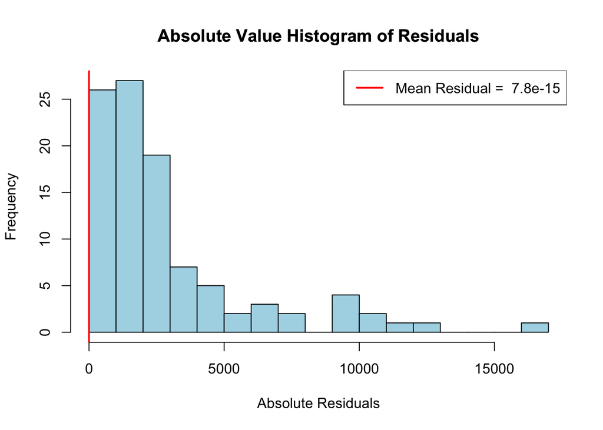

```r
# Creating residuals and mean_residual objects
residuals <- model$residuals
mean_residual <- mean(residuals)

# Rounding mean_residual to 1 decimal place for display purposes
formatted_x <-  sprintf("%.1e", mean_residual)

# creating histogram
hist_abs_residuals <- hist(abs(residuals),
                           breaks = "fd",
                           main = "Absolute Value Histogram of Residuals",
                           xlab = "Absolute Residuals",
                           ylab = "Frequency",
                           col = "lightblue")

# Adding a vertical line for the mean value of residuals
abline(v = mean_residual, col = "red", lwd = 2)

# Adding a legend
legend("topright",
       legend = paste("Mean Residual = ", formatted_x),

       # Coloring mean_residual line
       col = "red", lwd = 2)

# Adding a title
title("Absolute Value Histogram of Residuals")
```

### Geographic Distribution

```r
NC$Residuals <- model$residuals
write_sf(NC, "NC.shp")
```

# Question 4

Create a choropleth map of the residuals of the regression with an appropriate legend and title. You may explore the spatial patterning fo residuals through altering your break methods and number of categories, but for your final map, use 4 classes and a quartiles classification theme. Why? This utilizes the median and 1st/3rd quartiles as breakpoints. In other words, our map will be connected to a measure of central tendency of the residuals, which can aid interpretation. Explain in writing if there is visual evidence for spatial dependence in the map. Provide the map and your R code.

```r
NC
```

```
## Simple feature collection with 100 features and 51 fields
## Geometry type: MULTIPOLYGON
## Dimension:     XY
## Bounding box:  xmin: -84.32377 ymin: 33.88216 xmax: -75.45658 ymax: 36.58977
## Geodetic CRS:  NAD83
## # A tibble: 100 × 52
##    NAME     AREA POP1990 POP2000 POP90_SQMI HOUSEHOLDS MALES FEMALES WHITE BLACK
##  * <chr>   <dbl>   <dbl>   <dbl>      <int>      <int> <int>   <int> <int> <int>
##  1 Ashe     439.   22209   24491         51       8848 10748   11461 21960   144
##  2 Allegh…  236.    9590    9887         41       3894  4625    4965  9338   177
##  3 Surry    550.   61704   68704        112      24252 29562   32142 58383  2780
##  4 Currit…  268.   13736   18837         51       5038  6920    6816 12051  1545
##  5 Northa…  587.   20798   21215         35       7591 10059   10739  8397 12328
##  6 Hertfo…  374.   22523   21886         60       8150 10444   12079  9214 12970
##  7 Camden   238.    5904    6968         25       2180  2960    2944  4388  1481
##  8 Gates    349.    9305   10259         27       3352  4597    4708  5101  4180
##  9 Warren   455.   17265   18974         38       6305  8272    8993  6593  9847
## 10 Stokes   476.   37223   44547         78      14123 18278   18945 34917  2069
## # ℹ 90 more rows
## # ℹ 42 more variables: AMERI_ES <int>, ASIAN_PI <int>, OTHER <int>,
## #   HISPANIC <int>, AGE_UNDER5 <int>, AGE_5_17 <int>, AGE_18_29 <int>,
## #   AGE_30_49 <int>, AGE_50_64 <int>, AGE_65_UP <int>, NEVERMARRY <int>,
## #   MARRIED <int>, SEPARATED <int>, WIDOWED <int>, DIVORCED <int>,
## #   HSEHLD_1_M <int>, HSEHLD_1_F <int>, MARHH_CHD <int>, MARHH_NO_C <int>,
## #   MHH_CHILD <int>, FHH_CHILD <int>, HSE_UNITS <int>, VACANT <int>, …
```

```r
library(tmap)
```

```r
library(sp)


### The following code has been commented out. It works, but is ugly. Couldnt figure out how to change the color, but leaving here to refer back to later

## Creating sf (spatial) object from NC df
#sf_object_NC <- st_as_sf(NC)

## passing the spatial object through the qtm() function and filling/coloring with residuals
#qtm(shp = sf_object_NC, fill = "Residuals")
```

[output not shown]

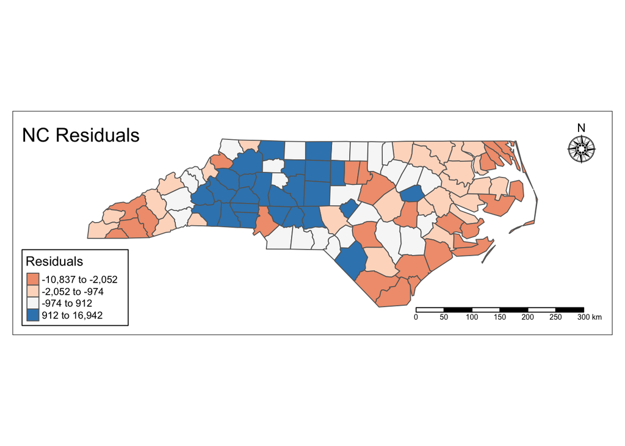

```r
# I liked this map better
tm_shape(NC) +
  tm_polygons(

    # Data variable being filled for chloropleth
    col = "Residuals",

    # Title / Color palette
    title = "Residuals",
    palette = "RdBu",

    # Number of classes
    n = 4,

    # Method of creating classes (quantile generally preferred)
    style = "quantile") +

  # Adding Scale Bar, Default position is "right","bottom"
   tm_scale_bar() +

  # Adding compass rose
  tm_compass(position = c("right", "top"), type = "rose", size = 2) +

  # Final formatting adjustments
  tm_layout(legend.outside = FALSE,
          title = "NC Residuals",
          inner.margins = .125,
          legend.frame = TRUE
          )
```

**Answer**

I really am not completely sure what the question means by spatial dependence. In aggregate it looks like the high and low values approximately balance one another out, which comports with the plot/ histogram in Question 3, i.e., the mean residual is essentially zero. However, if we are looking at clustering, and that is what is being referred to as spatial dependence - which makes the most sense to me, then yeah there’s a well defined pattern of clustering. High values are close to high values, low values are close to low values, and values near the mean are close to other values near the mean. This provides a visualization of where observed values miss above or below our regression line and to what relative degree they miss.